# Assessing inter-rater and intra-rater agreement

Thomas Weissensteiner

2025-01-09

**My scripts:**

- rendered html versions: [Rpubs/thomas-weissensteiner](https://rpubs.com/thomas-weissensteiner)
- .rmd files with executable code chunks: www.github.com/thomas-weissensteiner/portfolio/tree/main/

**About myself:** www.linkedin.com/in/ThomasWs-Mopfair

### 1. Background and motivation

#### 1.1. The challenge

“Wonderful Wednesdays” are a monthly webinar organised by the Visualisation Special Interest Group of Statisticians in the Pharmaceutical Industry ([PSI](https://psiweb.org/)). Participants are invited to address a visualisation challenge by submitting images and code which are discussed at the following meeting.

Here, the task involved comparing two methods of measurement, based on data from a paper by Eliasziw et al., 1994 <sup>1</sup>:

- one therapist uses two different instruments (electro and manual goniometers) to measure knee joint angles
- twenty-nine subjects (n=29) were measured three consecutive times on each goniometer at full passive joint extension

The visualisation should answer

- do the two goniometers agree?
- do the goniometers perform consistently across the three repeated measurements?

A [video](https://psiweb.org/vod/item/psi-vissig-wonderful-wednesday-57-intra--and-interrater-reliability) and [blog post](https://vis-sig.github.io/blog/posts/2024-12-20-wonderful-wednesdays-december-2024/) of the webinar are available from the PSI website.

#### 1.2. Reliability and agreement

In the terminology that will be used here, the level of inter-rater *agreement* means how frequently two or more raters or methods can be expected to give *exactly the same* result. Inter-rater *reliability* refers to the consistency with between raters, or the degree by which their results are *proportional* when expressed as deviation from the mean. Therefore, it can be expressed as a correlation coefficient or analysis of variance. Reliability can be considered as a necessary but not sufficient condition to demonstrate agreement. Agreement and reliability are also sometimes referred to as absolute and relative reliability, respectively <sup>2</sup>.  
Different methods for assessing the agreement and/or reliability of measurements exists. The most common indices in the medical literature are

- hypothesis testing for bias, e.g comparing means (paired t-test)
- correlation coefficients, e.g. Pearson’s r (reliability)
- standard error of measurement
- repeatability coefficient
- Bland and Altman limits of agreement (mainly for agreement)  
  These methods do not have clear definitions of a null hypothesis. Rather, they are used to test for levels of agreement or reliability that should be defined as clinically acceptable prior to the analysis <sup>2,3</sup>.  
  x In the following sections, I will focus on visualisations of means and standard errors, Bland-Altman limits with exact confidence intervals <sup>4</sup>, Probability of Agreement <sup>5</sup>, and a new method that introduces statistical tests for accuracy, precision, and agreement <sup>6</sup>.

### 2. R packages and data set

Data, first 7 lines

```r
# - libraries_and_data                                                       - #

# Data manipulation
library(readxl)       # version 1.4.3  # read_excel
library(dplyr)        # version 1.1.4  # general grammar
library(purrr)        # version 1.0.2  # list_rbind, set_names
library(tidyr)        # version 1.3.1  # pivot_longer, pivot_wider

# Graphics
library(gridExtra)    # version 2.3    # tableGrob
library(ggplot2)      # version 3.4.0
library(ggside)       # version 0.3.1  # geom_ysidedensity (density side plots)
library(ggiraph)      # version 0.8.10 # girafe, geom_..._interactive (interactive plots)
library(patchwork)    # version 1.3.0  # plot_spacer, plot_layout, plot_annotation (assembly of interactive plots)

# Visual and statistical assessments of accuracy, precision and agreement
library(eirasagree)    # version 5.1

library(kableExtra)   # rendering tables in HTML format


# Working directory

setwd("C:/Users/ThomasWeissensteiner/OneDrive/Documents/portfolio/WWchallenges/WWchallenge_57")


# Data, were downloaded manually into the working directory from https://github.com/VIS-SIG/Wonderful-Wednesdays/tree/master/data/2024/2024-11-13

data <- read_excel("goniometer.xlsx")

data <-
  data %>%
  rename(
    Id = id,
    Replicate = time,
    Method = rater,
    Value = y
    ) %>%
  mutate(
    Replicate =  case_when(
      Replicate == "1" ~"1st",
      Replicate == "2" ~"2nd",
      Replicate == "3" ~"3rd"
      ) %>% factor,
    Method =  case_when(
      Method == "manual" ~"Manual",
      Method == "electro" ~"Electro"
      ) %>%
      factor(
        levels = c("Manual", "Electro")
        ),
      Id = factor(Id)
    )

# Data with new variable names

data %>% .[1:7,]
```

```
## # A tibble: 7 × 4
##   Id    Replicate Method  Value
##   <fct> <fct>     <fct>   <dbl>
## 1 1     1st       Manual     -2
## 2 1     1st       Electro     2
## 3 1     2nd       Manual      0
## 4 1     2nd       Electro     1
## 5 1     3rd       Manual      1
## 6 1     3rd       Electro     1
## 7 2     1st       Manual     16
```

### 3. Distribution of measured values

#### 3.1. Raw data: consecutive replicate measurements with two different methods

```r
# - Chunk_1                                                           - #
# - Requires:  * R-libraries and object data (libraries_and_data)     - #


## Plot of measurements in individual subjects versus replicate number

p1 <-
  data %>%
  ggplot(
    aes(
      x = as.numeric(Replicate),
      y = Value,
      color = Id,
      data_id = Id,
      tooltip = Id
      )
    ) +
  geom_line(color = "lightgrey") +
  geom_point_interactive() +
  facet_wrap(.~Method) +
  scale_x_continuous(
    breaks = 1:3,
    labels = levels(data$Replicate)
    ) +
  xlab("Replicate") +
  ylab("Measured value") +
  labs(
    title = "Consecutive replicate measurements in individual patients",
    caption = "Hover over a point to highlight individual patient ids"
    ) +
  theme_light() +
  theme(
    plot.title = element_text(hjust = 0.5),
    strip.background = element_blank(),
    strip.text.x = element_text(
      color = "black",
      size = 10
      ),
    legend.position = "none",
    plot.caption = element_text(hjust=0.5)
    )


girafe(
  ggobj = p1,
    options = list(
    opts_hover(css = ''),                       # CSS code of selected line
    opts_hover_inv(css = "opacity:0.05;"),      # CSS code of all other lines
    opts_sizing(rescale = FALSE)
    )
  )
```

[interactive chart not shown]

Manual measurements were spread over a greater range and tended to be somewhat higher than the values obtained with the electro method.  
Raw data show no obvious trends across repeated measurements for either method.  
*Note on coding: There is presently no reliable function in ggiraph for interactive line plots, i.e. lines that cross each other tend to respond as a group. As a substitute, I used geom_point_interactive although coloured lines would have been visually more appealing.*

#### 3.2. Comparing means, variances, and repeatabilities of the original measurements

Plotting the distribution of the data can help checking whether two statistical assumptions of the Bland-Altman method are met: Variance for both methods should a) be of similar magnitude, and b) not depend on the true latent trait <sup>3,7</sup>. Mean and standard error give a first indication of method agreement.

```r
# - Chunk_2                                                             - #
# - Requires:  * R-libraries and object data (libraries_and_data)       - #


# Standard error function

std <- function(x) sd(x)/sqrt(length(x))

# Calculate intra-subject replicate means

replicates <- data %>% .$Replicate %>% levels

data_replMean <-
  data %>%
  pivot_wider(
    names_from = "Replicate",
    values_from = "Value") %>%
  rowwise() %>%
  mutate(
      replicate_Mean = mean(
        c_across(
          all_of(replicates)
          )
        ),
      replicate_SD = sd(
        c_across(
          all_of(replicates)
          )
        ),
      replicate_SE = std(
        c_across(
          all_of(replicates)
          )
        )
      ) %>%
  pivot_longer(
    cols = all_of(replicates),
    names_to = "Replicate",
    values_to = "Value"
  ) %>%
  mutate(
    Replicate = factor(Replicate)
  )

## Table with summary statistics of the original sample data

# Generate summary table

data_replMeanMean <-
  data_replMean %>%
  { rbind(
      group_by (., Method, Replicate) %>%     # for each method and replicate, calculate mean and SE across subjects
      summarise(
        Mean = mean(Value),
        SD = sd(Value),
        SE = std(Value)
        ),
      group_by (., Method) %>%           # for each method, calculate means across subjects for mean and SE across replicates
      summarise(
        Mean = mean(replicate_Mean),
        SD = sd(replicate_Mean),
        SE = std(replicate_Mean)
        ) %>%
        mutate(Replicate = "replicate mean")
      )
  } %>%
  mutate(                 # vertical offset for error bars and their means in the plots
    errorbar_pos = rep(- 0.06, n()),
    Replicate = factor(Replicate)
    )


## Plots

palette_1 <- c("blue", "red")

# Distribution, mean and SE for individual replicates and their means

p2A <-
data_replMean %>%
  bind_rows(
    data_replMean %>%
    filter(Replicate == "1st") %>%          # select a unique row for each subject's replicate mean
    mutate(
    .keep = "unused",
    Replicate = "replicate mean",
    Value = replicate_Mean)
  ) %>%
  select(Id, Replicate, Method, Value) %>%
  ggplot(
    ) +
  geom_density(                             # show smoothed distribution of measurement values
    aes(
      Value * 0.7,
      fill = Method
      ),
    alpha = 0.3,
    color = "grey",
    position = position_nudge(y = 0.02)
    ) +
  geom_point_interactive(                   # show data points of all subjects
    aes(
      x = Value,
      y = -0.02,                            # vertical offset for data point rows
      color = Method,
      data_id = Id,
      tooltip = Id
      ),
    size = 3,
    alpha = 0.5
    ) +
  geom_errorbarh (                          # show SE bar
    data = data_replMeanMean,
    #inherit.aes = FALSE,
    aes(
      xmin = Mean - SE,
      xmax = Mean + SE,
      y = errorbar_pos - 0.025,
      color = Method
      ),
      height = 0.025                       # height of bar caps
    ) +
  geom_errorbarh (                         # show SD bar
    data = data_replMeanMean,
    #inherit.aes = FALSE,
    aes(
      xmin = Mean - SD,
      xmax = Mean + SD,
      y = errorbar_pos,
      color = Method
      ),
      height = 0.04                        # height of bar caps
    ) +
  geom_point(                              # add means to SE bars
    data = data_replMeanMean,
     aes(
      x = Mean,
      y = errorbar_pos,
      color = Method
      ),
      shape = 18,
      size = 3
    ) +
  facet_wrap(
    .~ Replicate,
    dir = "v",
    strip.position = "left",
    nrow = 4
    ) +
  labs(
    title = "Inter-method comparison of mean, SD and SE",
    y = "Replicate",
    x = "Measurement",
    tag = "A"
    ) +
  scale_fill_manual( values = palette_1) +
  scale_color_manual(values = palette_1) +
  guides(
    fill = guide_legend(title="Method"),
    color = guide_legend(title="Method")
    ) +
  theme_light() +
  theme(
    plot.title = element_text(
      size = 12,
      hjust = 0.5),
    axis.text.y = element_blank(),
    strip.background = element_rect(
      fill = "white",
      color = "darkgrey"
      ),
    axis.ticks.y = element_blank(),
    strip.text.y = element_text(
      color = "black",
      size = 12
      )
    )


# Consistency of results over repeated measurements

p2B <-
data_replMeanMean %>%
  filter (!Replicate == "replicate mean") %>%
  mutate(
    SEup = Mean + SE,
    SElow = Mean - SE
    ) %>%
  select(!c(errorbar_pos, SD, SE) ) %>%
  ggplot(
    aes(
      x = as.numeric(Replicate),
      y = Mean,
      #group = Method,
      color = Method,
      fill = Method
      )
    ) +
  geom_ribbon(
    aes(ymin =SElow, ymax = SEup),
    linetype = 0,
    alpha = 0.2
    ) +
  geom_line() +
  scale_color_manual(values = palette_1) +
  scale_fill_manual(values = palette_1) +
  scale_x_continuous(
    breaks = 1:3,
    labels = levels(data$Replicate)
    ) +
  labs(
    title = "Repeatability over consecutive
    replicate measurements",
    x = "Replicate",
    y = "Mean +/- SE",
    tag = "B"
    ) +
  theme_light() +
  theme(
    plot.title = element_text(
      size = 12,
      hjust = 0.5
      ),
    legend.position = "none"
    )


# Variance versus value of replicate means

p2C <-
data_replMean %>%
  filter(Replicate == "1st") %>%             # select a unique row for each subject's replicate mean (avoid generating one row for each replicate)
  ggplot(
    aes(
      x = replicate_Mean,
      y = replicate_SD,
      color = Method,
      fill = Method
      )
    ) +
  geom_point_interactive(             # show data points of for replicate means of all subjects
    aes(
      data_id = Id,
      tooltip = Id
      ),
    size = 3,
    alpha = 0.5
    ) +
  geom_smooth(
    lwd = 0.1,
    alpha = 0.1
    ) +
  scale_color_manual(values = palette_1) +
  scale_fill_manual(values = palette_1) +
  labs(
    title = "Replicate variance versus mean",
    caption =  "Hover over points to highlight individual patients",
    x = "Replicate mean",
    y = "SD",
    tag = "C"
    ) +
  theme_light() +
  theme(
    plot.title = element_text(
      size = 12,
      hjust = 0.5),
    plot.caption = element_text(
      size = 9,
      hjust = 0.5),
    legend.position = "none"
    )


# Deviation of individual measurements from replicate means
# (alternative to the SD versus value plot, p2C)

p2D <-
  data_replMean %>%
  mutate(Residuals = Value - replicate_Mean) %>%
  ggplot(
    aes(
      x = Value,
      y = Residuals,
      color = Method,
      fill = Method
      )
  ) +
  geom_point_interactive(
    aes(
      data_id = Id,
      tooltip = Id
      ),
    size = 2,
    alpha = 0.5
    ) +
  geom_hline(
    aes(yintercept = 0),
    color = "darkgrey"
    ) +
  geom_ysidedensity(
    aes(y = Residuals),
    alpha = 0.1
    ) +
  scale_color_manual(values = palette_1) +
  scale_fill_manual(values = palette_1) +
  labs(
    title = "Deviation from replicate mean",
    x = "Measurement",
    y = "Measurement - Replicate mean",
    tag = "D"
    ) +
  theme_light() +
  theme(
    plot.title = element_text(
      size = 12,
      hjust = 0.5
      ),
    axis.text.y = element_text(
      size = 9
      ),
    legend.position = "none"
    ) +
  theme_ggside_void()


# Combined plot layout

design <- "AAAAA#BBBB
           AAAAA#BBBB
           AAAAA#BBBB
           AAAAA#####
           AAAAA#####
           AAAAA#E###
           AAAAA#####
           AAAAA#####
           CCCCC#DDDD
           CCCCC#DDDD
           CCCCC#DDDD"

girafe(
  ggobj =
    p2A +
    p2B +
    p2C +
    p2D +
    guide_area() +
    plot_annotation(
      title = "Distributions and means of original measurements\n",
      theme = theme(
        plot.title = element_text(
          size = 14,
          hjust = 0.5
          )
        )
      ) +
    plot_layout(
      design = design,
      guides = "collect"
      ),
    height_svg = 11,
    width_svg = 9,
    options = list(
      opts_hover(css = "stroke:black; stroke-width:2px;"),  # CSS code of selected line
      opts_hover_inv(css = "opacity:0.1;"),                 # CSS code of all other lines
      opts_sizing(rescale = FALSE)                          # allows to zoom in and out of saved html image
      )
  )
```

[interactive chart not shown]

```r
# Display summary table

data_replMeanMean %>%
  select(!errorbar_pos) %>%
  kable(., "html") %>%
  kable_styling(
    bootstrap_options = c(
      "striped", "hover", "responsive", full_width = FALSE
      )
    )
```

| Method | Replicate | Mean | SD | SE |
| --- | --- | --- | --- | --- |
| Manual | 1st | 1.5862069 | 7.218613 | 1.3404628 |
| Manual | 2nd | 1.4827586 | 7.471951 | 1.3875064 |
| Manual | 3rd | 1.2413793 | 7.452972 | 1.3839822 |
| Electro | 1st | 0.0000000 | 7.086204 | 1.3158750 |
| Electro | 2nd | 0.0344828 | 7.480846 | 1.3891582 |
| Electro | 3rd | 0.1034483 | 7.148151 | 1.3273783 |
| Manual | replicate mean | 1.4367816 | 7.263108 | 0.7786869 |
| Electro | replicate mean | 0.0459770 | 7.109729 | 0.7622430 |

Note that standard deviations and errors for the replicate means show in the fourth row of (A) are not entirely correct: Overall variance should account for both within-sample and between-sample variation, but shown here is only the latter which is an underestimate. Because replicates within a sample are also correlated, more appropriate methods for their calculations would be:

- Mixed-effects model or variance components analysis (e.g. R package lme4)
- Nested ANOVA (Analysis of Variance)

#### 3.3. Differences between measurements for each replicate and the replicate mean: do they have normal distribution?

The Bland-Altman method for assessing method equivalence also requires that differences between the methods are normally distributed <sup>3,7</sup>.  
Histograms and probability (or quantile-quantile / qq) plots are common ways for visualising how well distributions conform with normality: On the left, black bars represent binned actual values while red lines show their theoretical normal distributions. For data with a perfect normal distribution, the histogram bars will fill the area under the line.  
On the right, quantiles of actual values are plotted against their theoretical quantiles. In case of a perfectly normal distribution, all points will lie on the dashed red line.

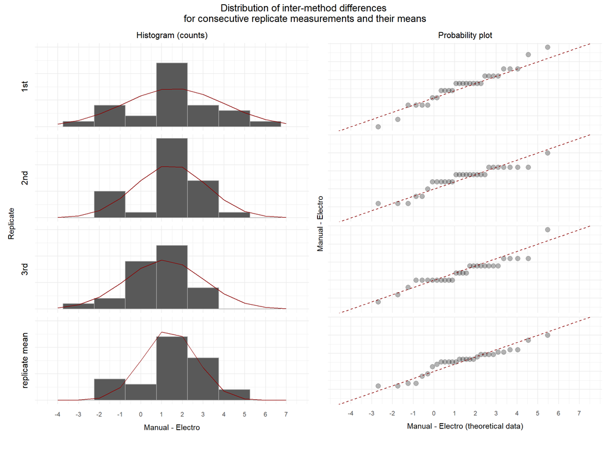

```r
# - Chunk_3                                                                      - #
# - Requires:  * R-libraries and object data (libraries_and_data),               - #
#              * data_replMean (chunk 2)                                         - #
#              * samples to be numbered 1:n, in same order as theoretical values - #


## Inter-replicate means and SDs for differences and means (chunk 3) of measurements for each sample

# Differences and means of measurements with the two methods for each sample and replicate

data_BlAltm <-
  data_replMean %>%
    select(Id, Replicate, Method, Value) %>%
    pivot_wider(
        names_from = "Method",
        values_from = "Value"
    ) %>%
  mutate(
    Method_mean = (Manual + Electro)/2,
    Method_diff = Manual - Electro
    )

# Differences and means of measurements with the two methods: replicate means for each sample

# Question: Does considering only the variance of the measurement differences, instead of intra-replicate variance of each rater/method of measurement lead to an underestimation of SDs? Would mixed-effects models or nested ANOVA, also suggested for the nested SDs below, be more appropriate?

data_BlAltm_replMeans <-
  data_BlAltm %>%
  select(Id, Replicate, Method_mean, Method_diff) %>%
  split(.$Id) %>%
  lapply(
    function(x) summarise(x,
      Mean_methodMean = mean(Method_mean),
      SD_methodMean = sd(Method_mean),
      Mean_methodDiff = mean(Method_diff),
      SD_methodDiff = sd(Method_diff)
      )
    ) %>%
  list_rbind(names_to = "Id")

# Combine the 2 dataframes above

data_BlAltm_combined <-
 data_BlAltm %>%
  select(Id, Replicate, Method_diff, Method_mean) %>%
  bind_rows(
    data_BlAltm_replMeans %>%
    mutate(
      Id = Id,
      Replicate = "replicate mean",
      Method_diff = Mean_methodDiff,
      Method_mean = Mean_methodMean,
      .keep = "none"
      )
    )


## Limits of agreement (LoA) for all inter-replicate means and overall mean of method differences

# Function for calculating nested SDs

SD_nested <-
  function(x) {
    sqrt(sum(x^2)/(length(x)-1))
    }

data_BlAltm_replLoA <-
  data_BlAltm %>%
  group_by(Replicate) %>%
  summarise(
    Mean = mean(Method_diff),
    SD = sd(Method_diff),
    LoA_up = Mean + 1.96* SD,
    LoA_low = Mean - 1.96* SD
    )

data_BlAltm_LoA_replMeansMeans <-
  data_BlAltm_replMeans %>%
  summarise(
    Mean = mean(Mean_methodDiff),
    SD = SD_nested(SD_methodDiff)
    ) %>%
  mutate(
    LoA_up = Mean + 1.96*SD,
    LoA_low = Mean - 1.96*SD
    )

# Combine the 2 dataframes above

data_BlAltm_LoA_combined <-
 data_BlAltm_replLoA %>%
  select(Replicate, Mean, SD) %>%
    bind_rows(
    data_BlAltm_LoA_replMeansMeans %>%
      mutate(Replicate = "replicate mean") %>%
      select(Replicate, Mean,  SD)
      )

# Add theoretical values with normal distribution

data_BlAltm_combined <-
  full_join(
    data_BlAltm_combined,
    data_BlAltm_LoA_combined %>%           # adding column with theoretical values
      apply(., 1,
        function(row) {dnorm(
          -14:14,                          # centers distribution
          mean = as.numeric(row['Mean']),
          sd = as.numeric(row['SD'])
          )
          }
        ) %>%
      {.*29} %>%                          # scale distribution to total number of samples
      as.data.frame() %>%
      mutate(Id = factor(1:29) ) %>%
      pivot_longer(
        cols = !"Id",
        names_to = "Replicate",
        values_to = "Theor_method_diff"
        ) %>%
      mutate(
        Replicate = rep(
          c("1st", "2nd", "3rd", "replicate mean"), 29
          )
        )
      )

## Plots

# Histogram plot of measurement differences

binwidth = 1.5           # results in 9 bins

p3A <-
 data_BlAltm_combined %>%
  mutate(
    Id = as.numeric(Id),
    x= Id - mean(Id)
  ) %>%
  ggplot() +
  geom_histogram(
    aes(Method_diff),
    binwidth = binwidth,
    position = "stack",
    color = "darkgrey"
    ) +
  geom_line(        # stat_function (mean, sd) would be result im smother line, but does not work with faceting
    aes(
      x = x,
      y = Theor_method_diff * binwidth),
      color = "darkred"
    ) +
  facet_wrap(
    .~ Replicate,
    dir = "v",
    strip.position = "left",
    nrow = 4
    ) +
  labs(
    title = "Histogram (counts)",
    x = "\nManual - Electro",
    y = "Replicate"
    ) +
  scale_x_continuous(
    limits = c(-4.5, 7.5),                    # set manually to match histogram bins (ignore warnings)
    breaks = seq(-4, 7, 1)
    ) +
  theme_minimal() +
  theme(
    plot.title = element_text(
      size = 12,
      hjust = 0.5),
    axis.text.y = element_blank(),
    strip.placement = "outside",
    strip.background = element_blank(),
    strip.text.y = element_text(
      color = "black",
      size = 12
      ),
    axis.ticks = element_blank(),
    axis.text.x = element_text(vjust = -2)
    )

# qq-plot of measurement differences (unscaled)

p3B <-
 data_BlAltm_combined %>%
  ggplot(
    aes(sample = Method_diff)
    ) +
  geom_qq(
    dparams = list(
      mean = mean(data_BlAltm_combined$Method_diff),
      sd = sd(data_BlAltm_combined$Method_diff)
      ),
    size = 3,
    color = "black",
    alpha = 0.3,
    ) +
   geom_abline(
    linetype = "dashed",
    slope = 1,
    intercept = 0,
    color = "darkred"
    ) +
    facet_wrap(
    .~ Replicate,
    dir = "v",
    strip.position = "left",
    nrow = 4
    ) +
  labs(
    title = "Probability plot",
    x = "\nManual - Electro (theoretical data)",
    y = "Manual - Electro"
    ) +
  scale_x_continuous(
    limits = c(-4.5, 7.5),                    # set manually to match histogram bins
    breaks = seq(-4, 7, 1)
    ) +
  theme_minimal() +
  theme(
    plot.title = element_text(
      size = 12,
      hjust = 0.5),
    strip.background = element_blank(),
    strip.text = element_blank(),
    axis.ticks = element_blank(),
    axis.text.y = element_blank(),
    axis.text.x = element_text(vjust = 6),
    axis.title.x = element_text(vjust = 13)
     )

p3A + p3B  +
  plot_layout(
    ncol = 2,
    heights = 6
    ) +
  plot_annotation(
    title = "Distribution of inter-method differences \nfor consecutive replicate measurements and their means",
    theme = theme(
      plot.title = element_text(
        size = 14,
        hjust = 0.5
        )
      )
    )
```

The plots show that method differences for individual replicates, as well as their means, have approximately normal distribution. Statistical tests for normality such as Shapiro-Wilk, D’Agostino-Pearson, Kolmogorov-Smirnov can be used to confirm normality. If rejected, a transformation of the original data may be tried. In certain cases, estimating the limits with a non-parametric method might be preferable <sup>3</sup>.